# Integração

Responda os seguintes itens:

a) Explique de maneira suscinta, mas clara e completa qual a diferença entre os métodos de integração numérica baseados nos métodos do trapézio, Simpson e Romberg.

b) Resolva o Exercício 5.4 de nosso livro-texto *Computational Physics* de *Mark Newman*.

## Método dos Trapézios

Consiste em subdividir a área delimitada em pequenos espaços de tamanho igual e considerar a área referente a um trapézio delimitado pelos pontos onde a curva toca os limites dessa pequenas área.

Quando maior o número de subdivisões, mais preciso é o resultado.

[figure not shown]

## Método de Simpson

Assim como o Método dos Trapézios, consiste em subdividir a área delimitada em pequenos espaços de tamanho igual, então também quando maior o número de subdivisões mais preciso é o resultado, contudo o método para calcular a área é utiliza 3 pontos essas subdiviões tocam a curta e é realizada uma aproximação quadratica, uma parabola, entre esses pontos.

[figure not shown]

## Método de Romberg

Utiliza uma abordagem diferente do método dos trapézios onde se considera os limites que se deseja calcular da curva e se faz um único trapézio entre as pontas.

A seguir, divide-se esse primeiro trapézio ao meio e com os novos limites se calcula novos dois trapézios com base no já calculado, e em cada um desses novos trapézios se divide em outros dois e calcula novos dois trapézios.

É fácil notar que por esse método podemos continuar o cálculo e assim aumentar a precisão do valor obtido, o que não é possivel pelo Método dos Trapézios ou pelo Método de Simpson, onde é necessário refazer todo o cálculo com maior número de subdivicões para obter um valor mais preciso.

[figure not shown]

### Bibliotecas utilizadas

```python
import math
import numpy as np
from scipy import integrate
import matplotlib.pyplot as plt
```

## Regra dos Trapézios

Equação e código obtidos na página 142 do livro *Computational Physics* de *Mark Newman*.

$$I(a, b) \simeq h \left[ \frac{1}{2} f(a) + \frac{1}{2} f(b) + \sum_ {k=1}^{N-1} f(a + kh) \right] $$

```python
def integracao_trapezios(f, a: float = 0.0, b: float = 1.0, n: int = 10)->float:
    h = (b - a) / n

    s = 0.5 * f(a) + 0.5 * f(b)
    for k in range(1, n):
        s += f(a + k * h)

    return h * s
```

## Método de Simpson

Equação obtida na página 147 do livro *Computational Physics* de *Mark Newman*.

$$I(a, b) \simeq \frac{1}{3} h \left[ f(a) + f(b) + 4 \sum_ {k=1}^{N/2} f(a + (2k - 1)h) + 2 \sum_{k=1}^{N/2 - 1} f(a + 2kh) \right] $$

```python
def integracao_simpson(f, a: float = 0, b: float = 1, n: int = 10)->float:
    h = (b - a) / n

    s = f(a) + f(b)
    for k in range(1, math.floor(n//2)):
        s += 4 * f(a + (2 * k - 1) * h)
        s += 2 * f(a + (2 * k * h))
    s += 4 * f(a + (2 * (k + 1) - 1) * h)

    return 1 / 3 * h * s
```

#### Exemplo 5.1 do Livro *Computational Physics* de *Mark Newman*.

$$\int_0^2 (x^4 - 2x + 1) dx$$

```python
def f(x):
    return x ** 4 - 2 * x + 1

a = 0.0
b = 2.0
n = 100

print("Regra dos Trapésios:", integracao_trapezios(f, a, b, n))
print("Regra de Simpson:   ", integracao_simpson(f, a, b, n))
print("SciPy padrão:       ", integrate.quad(f, a, b)[0])
```

```
Regra dos Trapésios: 4.401066656
Regra de Simpson:    4.400000042666666
SciPy padrão:        4.3999999999999995
```

#### b) Resolva o Exercício 5.4 de nosso livro-texto *Computational Physics* de *Mark Newman*.

### Função de Bessel

$$J_m(x) = \frac{1}{\pi} \int_{0}^{\pi} cos(m \theta - x sin \theta) d \theta$$

Resolva para $J_0(x)$, $J_1(x)$ e $J_2(x)$ para $x$ de $0$ a $20$, pelo Método de Simpson com $N = 1000$ e plote o gráfico.

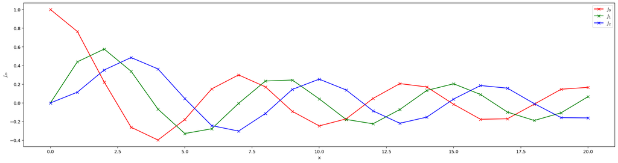

```python
def bessel(tetha, m, x):
    return 1/math.pi * (math.cos((m * tetha) - float(x) * math.sin(tetha)))

def bessel_m_x(tetha):
    global m
    global x
    return bessel(tetha, m, x)


a = 0.0
b = math.pi
n = 1000
X = 20

bessel_plot = [[0.0] * (X + 1) for _ in range(3)]
for m in range(3):
    for x in range(X + 1):
        bessel_plot[m][x] = integracao_simpson(bessel_m_x, a, b, n)


fig, axs = plt.subplots(1, 1, figsize=(24, 6), dpi = 180)
axs.set_xlabel('x')
axs.set_ylabel(r'$J_m$')
axs.plot(bessel_plot[0], 'rx-', label=r"$J_0$")
axs.plot(bessel_plot[1], 'gx-', label=r"$J_1$")
axs.plot(bessel_plot[2], 'bx-', label=r"$J_2$")
axs.legend()
fig.show()
```

### Intensidade da Difração Circular

$$I(r) = \left( \frac{J_1(kr)}{kr} \right)^2$$

onde $k = 2 \pi / \lambda$ e $\lambda = 500$nm, de $ r = 0$ até $r = 1000$nm e sabendo que $\lim_{x \to 0} J_1(x)/x = 1/2$.

```python
def intensity(r):
    global x
    global m

    comprimento_de_onda = 500
    k = 2 * math.pi / comprimento_de_onda

    a = 0.0
    b = math.pi
    n = 100

    m = 1
    x = k * r

    if x == 0:
        return (1/2) ** 2
    else:
        return (integracao_simpson(bessel_m_x, a, b, n) / x) ** 2
```

Modelo de gráfico de densidade adaptado do exemplo apresentado na página 109 do livro *Computational Physics* de *Mark Newman*.

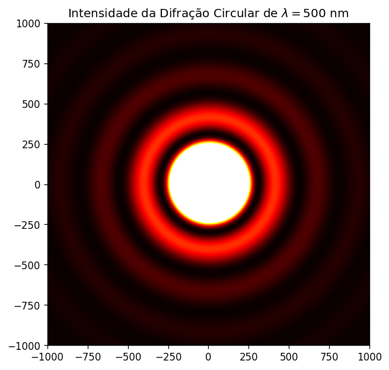

```python
raio_maximo = 1000
densidade_de_pontos = 200
quantidade_de_pontos = (raio_maximo * 2) // densidade_de_pontos

centro_x = raio_maximo
centro_y = raio_maximo

intensidade_plot = [[0.0] * densidade_de_pontos for _ in range(densidade_de_pontos)]
for i in range(densidade_de_pontos):
    y = quantidade_de_pontos * i
    for j in range(densidade_de_pontos):
        x = quantidade_de_pontos * j

        r1 = math.sqrt((x - centro_x) ** 2 + (y - centro_y) ** 2)
        intensidade_plot[i][j] = intensity(r1)

plt.hot()
fig, axs = plt.subplots(1, 1, figsize=(6, 6), dpi = 120)
axs.imshow(intensidade_plot, origin="lower", extent = [-raio_maximo,raio_maximo,-raio_maximo,raio_maximo], vmax=0.01)
axs.set_title(r'Intensidade da Difração Circular de $\lambda = 500$ nm')
fig.show()
```

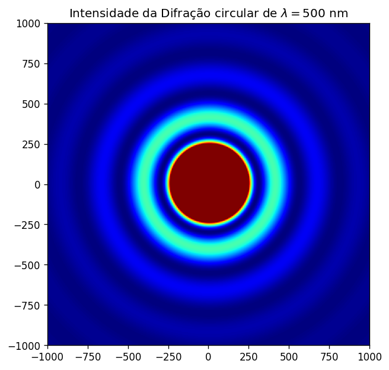

```python
plt.jet()
fig, axs = plt.subplots(1, 1, figsize=(6, 6), dpi = 120)
axs.imshow(intensidade_plot, origin="lower", extent = [-raio_maximo,raio_maximo,-raio_maximo,raio_maximo], vmax=0.01)
axs.set_title(r'Intensidade da Difração circular de $\lambda = 500$ nm')
fig.show()
```